# Analysis with Code COVID Africa

Monique Bennett

07/04/2020

```r
library(tidyverse)
library(wesanderson)
library(ggrepel)
library(extrafont)
library(readr)
library(countrycode)
```

## Introduction

The current COVID-19 pandemic presents a difficult road ahead for the Africa continent. Despite the continent having a slight “headstart” in preparing for the pandemic’s arrival, there are several risk factors that make the region vulnerable to the outbreak. The first case of COVID-19 was reported in Egypt on the 14th Feburary, since then the continent has recorded 8916 confirmed cases and 399 deaths. The analysis below will examine the continent’s public health sector and the health of the continent’s population. Unfortunately, there is still a significant shortage of reliable health data across the continent. The coverage of this analysis will include countries that have data available through the World Bank’s databank, which includes indicators from the Global Health Repository of the World Health Organisation (WHO).

```r
df_africa <- df_africa %>%
    as_tibble %>%
    filter(confirmed > 50) %>%
    group_by(country) %>%
    mutate(label = if_else(confirmed == max(confirmed), as.character(country), NA_character_)) %>%
    mutate(days_since_50 = as.numeric(date - min(date))) %>%
    ungroup

df_merged <- merge(df_africa, wb_africa, by = "iso3c")

breaks=c(50, 100, 200, 500, 1000, 2000, 5000, 10000, 20000, 50000, 100000)


df_current_covid <- data.frame(country = df_merged$country.x, iso3c = df_merged$iso3c,
                               total_confirm = df_merged$confirmed_cases,
                               total_deaths = df_merged$deaths_total,
                               popover65 = df_merged$SP.POP.65UP.TO.ZS,
                               cvd_cancer = df_merged$SH.DYN.NCOM.ZS,
                               non_comm = df_merged$SH.DTH.NCOM.ZS,
                               phys1000 = df_merged$SH.MED.PHYS.ZS,
                               smoke = df_merged$SH.PRV.SMOK)

df_current_covid <- unique(df_current_covid)

covid_current <- data.frame(country = df_africa$country, total = df_africa$confirmed_cases, iso3c = df_africa$iso3c)

covid_current <- unique(covid_current)

HDI_covid <- merge(HDI_afr, covid_current, by = "iso3c")

colnames(HDI_covid)[4] <- "HDI_score"
```

### Treadline of cases in Africa since the 50th Case (data from 06/04/2020)

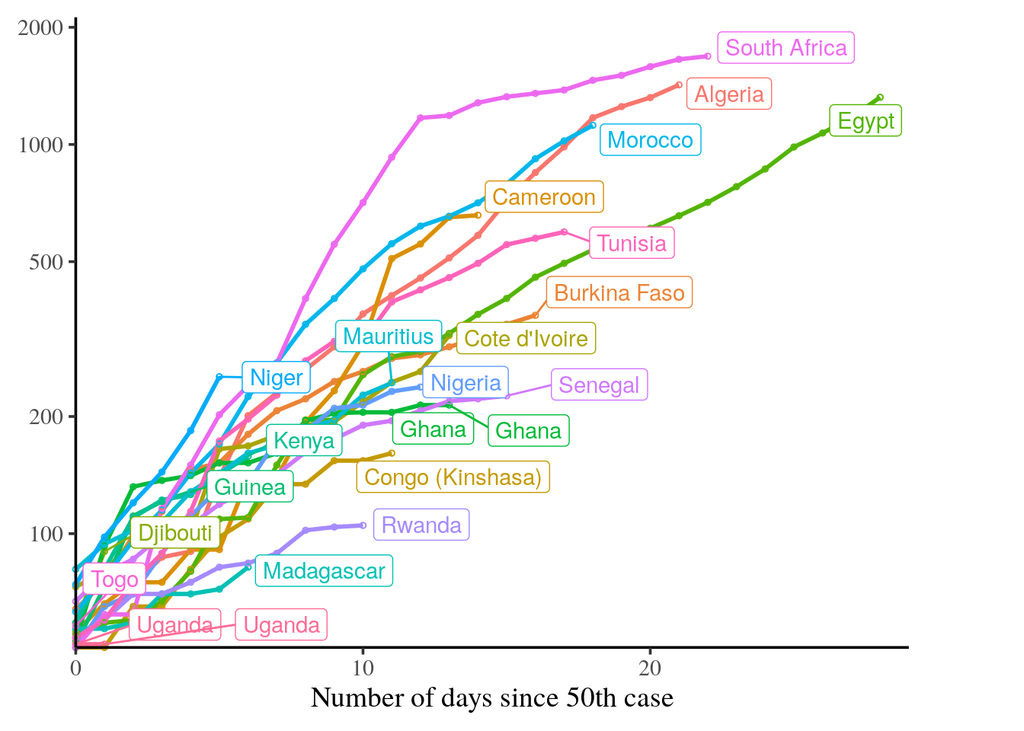

```r
pal2 <- wes_palette("Cavalcanti1", 54, type = "continuous")

ggplot(df_africa, aes(days_since_50, confirmed, color = country)) +
    geom_line(size = 1) +
    geom_point(pch = 21, size = 1) +
    geom_label_repel(aes(label = label),
                     nudge_x = 2, segment.size = 0.5) +
    scale_y_log10(expand = expansion(add = c(0,0.1)),
                  breaks = breaks, labels = breaks) +
    scale_x_continuous(expand = expansion(add = c(0,1))) +
    theme_classic(base_size = 14) +
    theme(
        panel.grid.minor = element_blank(),
        legend.position = "none",
        plot.margin = margin(3,20,3,3,"mm"),
        text = element_text(family = "serif")) +
    coord_cartesian(clip = "off") +
    labs(x = "Number of days since 50th case", y = NULL)
```

## Public Health Sector Overview

### Number of physicians per 10,000 people (%)

The graph below shows the number of doctors per 10,000 people for 19 countries in Africa averaged between the years 2010-2017. The distribution of the points reveals that most of the sample has a very low percentage of doctors per 10,000 people. This indicator helps measure the quality of healthcare and as is shown here, the continent performs very poorly.

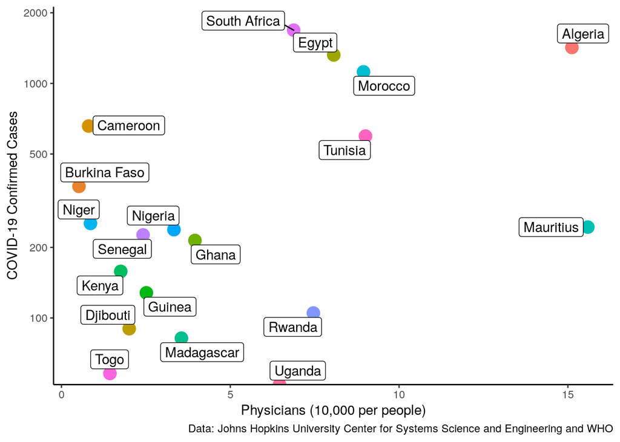

```r
doc <- read_csv("/home/monique/Documents/COVID rmarkdown/doctors_data.csv")
doc$iso3c <- countrycode(doc$country, origin = "country.name", destination = "iso3c")

doc_afr <- doc %>%
  filter( iso3c %in% c("DZA", "AGO", "BEN", "BWA", "BFA", "BDI", "CV", "CMR", "CAF", "TCD", "COM", "COD","COG", "CIV", "DJI", "EGY", "ERI", "SWZ", "ETH", "GAB", "GMB", "GHA", "GIN", "GNB",
"KEN", "LSO", "LBR", "LBY", "MDG", "MWI", "MLI", "MRT", "MUS", "MAR", "MOZ", "NAM","NER", "NGA", "RWA", "STP", "SEN", "SYC", "SLE", "SOM", "ZAF", "SSD", "SDN", "TZA", "TGO", "TUN", "UGA", "ZMB", "ZWE")) %>%
  drop_na() %>%
  rename(medical_docs = `Medical doctors (per 10 000 population)`) %>%
  group_by(country) %>%
  mutate(medical_docs_avg = mean(medical_docs)) %>%
  select(-year, -medical_docs)


doc_afr <- merge(doc_afr, covid_current, by = "country")
doc_afr <- unique(doc_afr)

ggplot(doc_afr) +
    geom_point(aes(x = medical_docs_avg, y = total, colour = country, size = 1.5,
                   stat = "unique"),
                  show.legend = FALSE) +
  scale_fill_gradientn(colours = pal2) +
  scale_y_log10(expand = expansion(add = c(0,0.1)),
                 breaks = breaks, labels = breaks) +
  geom_label_repel(aes(x = medical_docs_avg, y = total, label = country)) +
    guides(fill=FALSE) +
   xlab("Physicians (10,000 per people)") +
    ylab("COVID-19 Confirmed Cases") +
  labs(caption = "Data: Johns Hopkins University Center for Systems Science and Engineering and WHO") +
    theme(text = element_text(family = "serif")) +
    theme_classic()
```

### The use of basic handwashing facilities

The plots below indicate the use of basic sanitation and drinking water services across the African continent as of 2017. Each point represents the percentage of the population using basic sanitation services and drinking water services. The graph depicting the use of `at least basic sanitation services` indicates that more than half of the sample of African countries use less than 50% of sanitation services. What this might reveal is the strength of public health campaigns across the continent. The graph depicting the use of `basic drinking water services` is more evenly spread and there seems to be a much larger percentage utilising these services overall. What would be interesting to examine further is what relationship exists between access to sanitation and usage.

```r
wb_san_merged <- merge(df_africa, wb_sanitation, by = "iso3c")
```

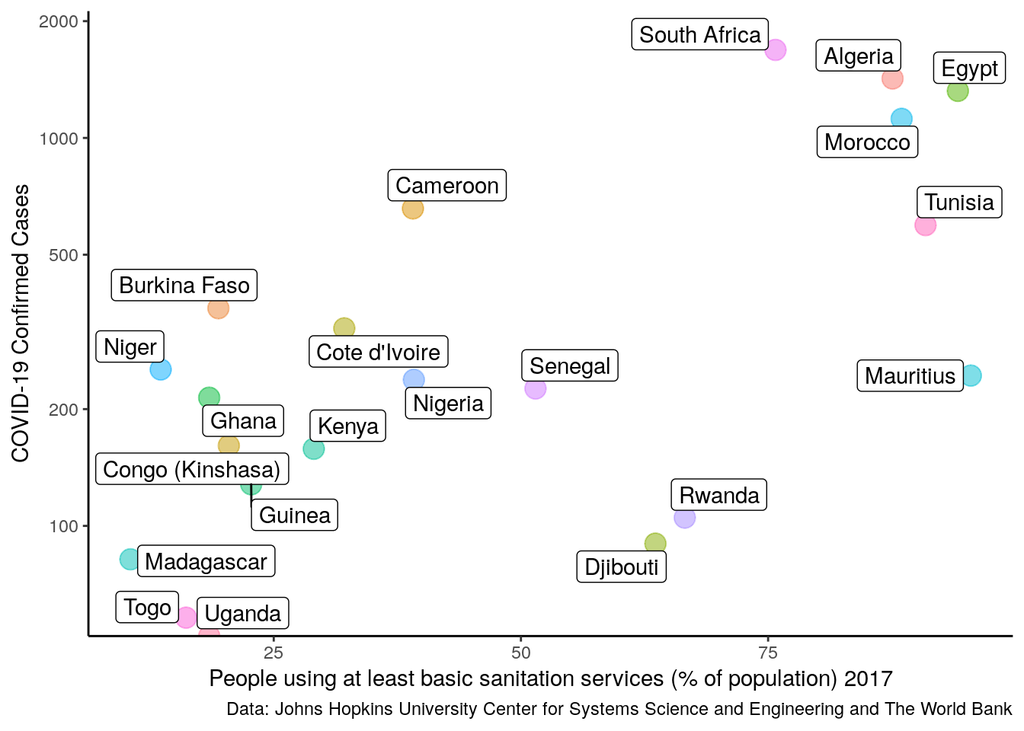

```r
wb_san_merged %>%
    filter(date.x == as.numeric(max(date.x))) %>%
ggplot() +
    geom_point(aes(x = SH.STA.BASS.ZS, y = confirmed_cases, colour = country.x,
                   size = 1.5),show.legend = FALSE,
               stat = "unique", alpha = 0.5) +
    scale_fill_gradientn(colours = pal2) +
    scale_y_log10(expand = expansion(add = c(0,0.1)),
                  breaks = breaks, labels = breaks) +
    geom_label_repel(aes(x = SH.STA.BASS.ZS, y = confirmed_cases, label = country.x)) +
    guides(fill=FALSE) +
    xlab("People using at least basic sanitation services (% of population) 2017") +
    ylab("COVID-19 Confirmed Cases") +
    labs(caption = "Data: Johns Hopkins University Center for Systems Science and Engineering and The World Bank") +
    theme(text = element_text(family = "serif")) +
    theme_classic()
```

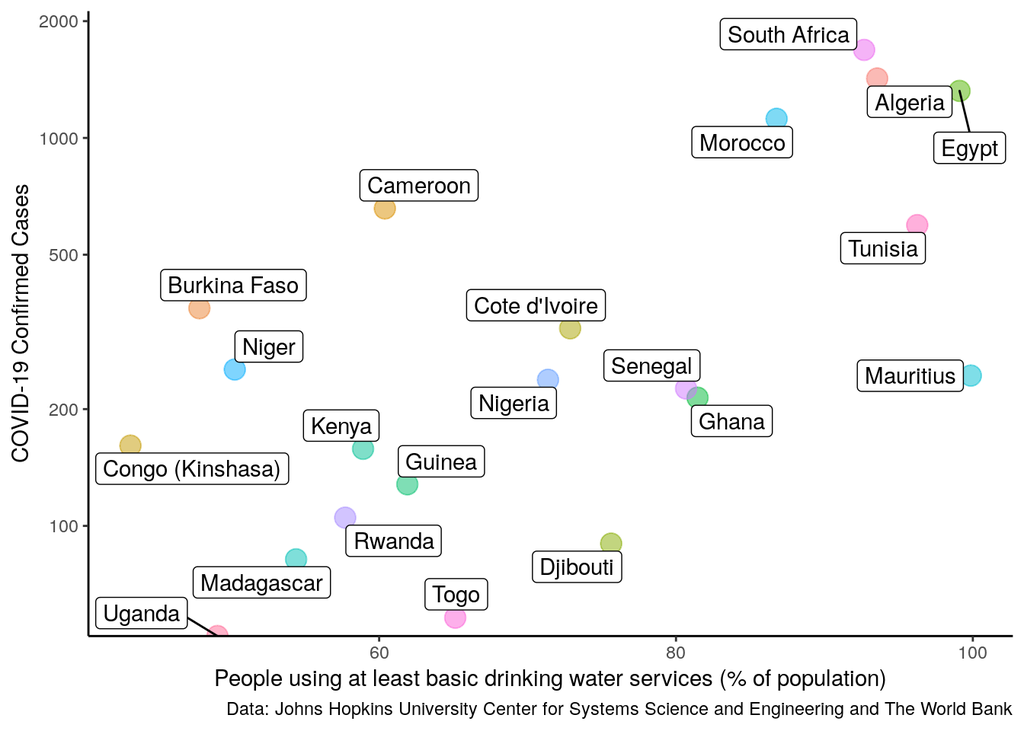

```r
wb_san_merged %>%
    filter(date.x == as.numeric(max(date.x))) %>%
ggplot() +
    geom_point(aes(x = SH.H2O.BASW.ZS, y = confirmed_cases, colour = country.x,
                   size = 1.5),show.legend = FALSE,
               stat = "unique", alpha = 0.5) +
    scale_fill_gradientn(colours = pal2) +
    scale_y_log10(expand = expansion(add = c(0,0.1)),
                  breaks = breaks, labels = breaks) +
    geom_label_repel(aes(x = SH.H2O.BASW.ZS, y = confirmed_cases, label = country.x)) +
    guides(fill=FALSE) +
    xlab("People using at least basic drinking water services (% of population)") +
    ylab("COVID-19 Confirmed Cases") +
    labs(caption = "Data: Johns Hopkins University Center for Systems Science and Engineering and The World Bank") +
    theme(text = element_text(family = "serif")) +
    theme_classic()
```

## Population over the age of 65

Evidence from the outbreak in both China and Italy indicate that people over the age of 65 may be at a higher risk of contracting a more severe case of COVID-19. What the graph below indicates is that the African population overall is young, most countries have less than 6% of their population over the age of 65. The size of the points represent number of deaths from COVID-19. There does not seem to be a clear pattern as yet in terms of age but this will need to be monitored over the next few months.

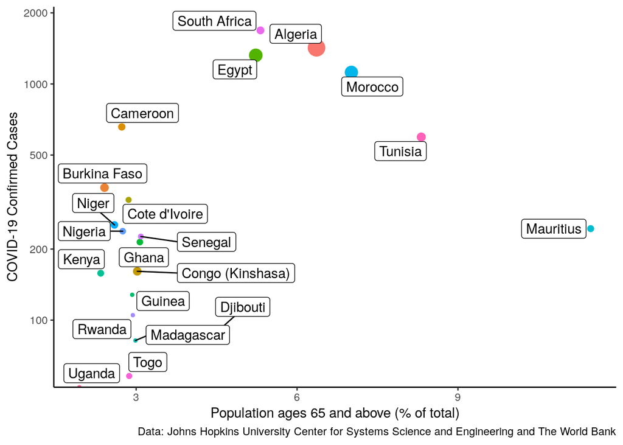

```r
df_current_covid %>%
    group_by(country) %>%
    filter(popover65 == max(popover65)) %>%
ggplot() +
    geom_point(aes(x = popover65, y = total_confirm, colour = country,
                   stat = "unique", size = total_deaths),
               show.legend = FALSE) +
    scale_fill_gradientn(colours = pal2) +
    scale_y_log10(expand = expansion(add = c(0,0.1)),
                  breaks = breaks, labels = breaks) +
    geom_label_repel(aes(x = popover65, y = total_confirm, label = country,
                         stat = "unique")) +
    guides(fill=FALSE) +
    xlab("Population ages 65 and above (% of total)") +
    ylab("COVID-19 Confirmed Cases") +
    labs(caption = "Data: Johns Hopkins University Center for Systems Science and Engineering and The World Bank") +
    theme_classic()
```

## Mortality from cardiovascular disease, diabetes or chronic respiratory disease.

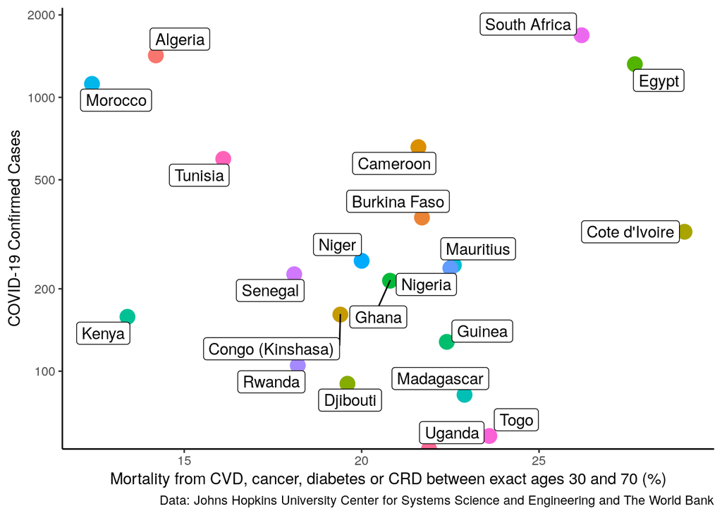

```r
ggplot(df_current_covid) +
    geom_point(aes(x = cvd_cancer, y = total_confirm, colour = country, size = 1.5),
               show.legend = FALSE, stat = "unique") +
    scale_y_log10(expand = expansion(add = c(0,0.1)),
                  breaks = breaks, labels = breaks) +
    geom_label_repel(aes(x = cvd_cancer, y = total_confirm, label = country)) +
    guides(fill=FALSE) +
    xlab("Mortality from CVD, cancer, diabetes or CRD between exact ages 30 and 70 (%)") +
    ylab("COVID-19 Confirmed Cases") +
    labs(caption = "Data: Johns Hopkins University Center for Systems Science and Engineering and The World Bank") +
    theme_classic()
```

## Impact of non-communicable diseases across the continent

Cause of death refers to the share of all deaths for all ages by underlying causes. Non-communicable diseases include cancer, diabetes mellitus, cardiovascular diseases, digestive diseases, skin diseases, musculoskeletal diseases, and congenital anomalies.

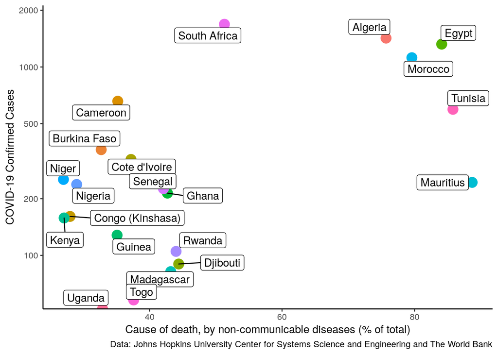

```r
ggplot(data = df_current_covid) +
    geom_point(aes(x =  non_comm, y = total_confirm, colour = country, size = 1.5),
               show.legend = FALSE) +
    scale_y_log10(expand = expansion(add = c(0,0.1)),
                  breaks = breaks, labels = breaks) +
    geom_label_repel(aes(x = non_comm, y = total_confirm, label = country)) +
    guides(fill=FALSE) +
    xlab("Cause of death, by non-communicable diseases (% of total)") +
    ylab("COVID-19 Confirmed Cases") +
    labs(caption = "Data: Johns Hopkins University Center for Systems Science and Engineering and The World Bank") +
    theme_classic()
```

## Smoking prevelance across the continent

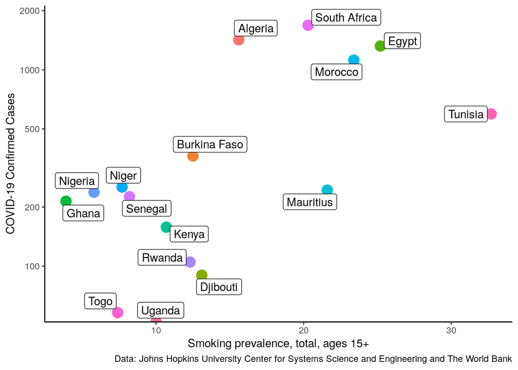

```r
ggplot(data = df_current_covid) +
    geom_point(aes(x = smoke, y = total_confirm, colour = country, size = 1.5),
               show.legend = FALSE) +
    scale_y_log10(expand = expansion(add = c(0,0.1)),
                  breaks = breaks, labels = breaks) +
    geom_label_repel(aes(x = smoke, y = total_confirm, label = country)) +
    guides(fill=FALSE) +
    xlab("Smoking prevalence, total, ages 15+") +
    ylab("COVID-19 Confirmed Cases") +
    labs(caption = "Data: Johns Hopkins University Center for Systems Science and Engineering and The World Bank") +
    theme_classic()
```

# Human Development Index

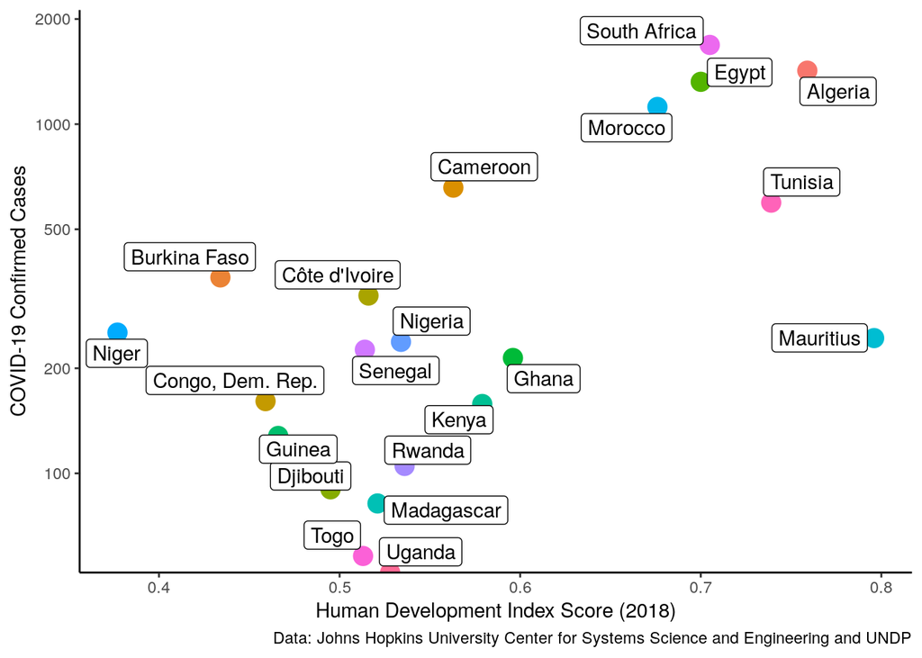

```r
ggplot(data = HDI_covid) +
    geom_point(aes(x = HDI_score, y = total, colour = country.x, size = 1.5),
               show.legend = FALSE) +
    scale_y_log10(expand = expansion(add = c(0,0.1)),
                  breaks = breaks, labels = breaks) +
    geom_label_repel(aes(x = HDI_score, y = total, label = country.x)) +
    guides(fill=FALSE) +
    xlab("Human Development Index Score (2018)") +
    ylab("COVID-19 Confirmed Cases") +
    labs(caption = "Data: Johns Hopkins University Center for Systems Science and Engineering and UNDP") +
    theme_classic()
```